# Имитационное моделирование

Лабораторная работа №2. Базовые модели SIR и Лотки–Вольтерры

Исаева Зарина Исмайилбековна

Российский университет дружбы народов имени Патриса Лумумбы

2026-09-05

# 1 Информация

## 1.1 Докладчик

- Исаева Зарина Исмайилбековна
- Студентка
- Российский университет дружбы народов имени Патриса Лумумбы
- Студенческий билет: 1132232882

# 2 Цель и задачи

## 2.1 Цель и состав работы

- Реализовать трёхпараметрическую модель SIR
- Исследовать модель Лотки–Вольтерры
- Выполнить базовые и параметрические сценарии
- Проверить качественные свойства решений
- Получить JL, IPYNB и QMD из литературного кода
- Сохранить таблицы, графики и контрольные показатели

# 3 Подготовка проекта

## 3.1 Структура и окружение

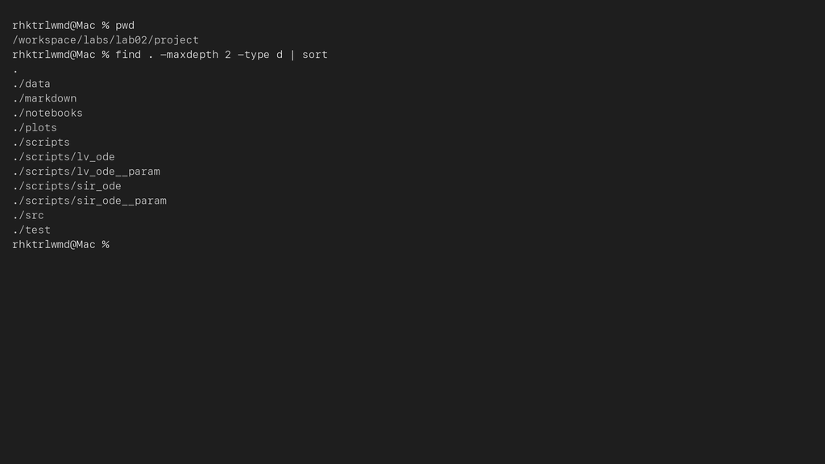

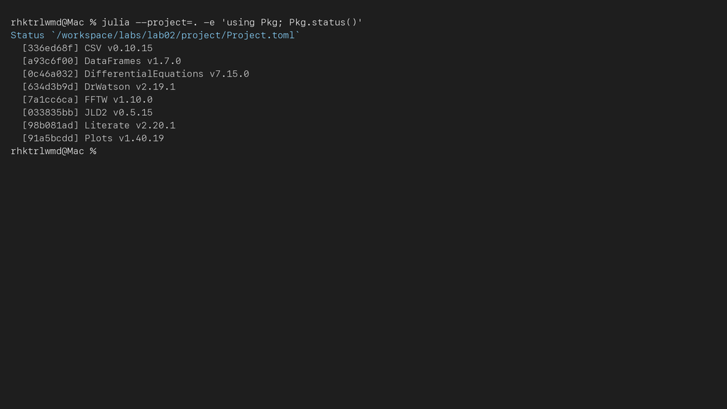

- четыре сценария используют один модуль моделей
- версии зависимостей закреплены в `Manifest.toml`

# 4 Модель SIR

## 4.1 Уравнения и репродуктивное число

$$\begin{aligned}
S'&=-\beta cIS/N,\\
I'&=\beta cIS/N-\gamma I,\\
R'&=\gamma I,
\end{aligned}
\qquad
R_0=\frac{\beta c}{\gamma}.$$

- $\beta$ — вероятность заражения; $c$ — контакты
- пик $I$ возникает при прохождении $R_e=R_0S/N$ через единицу

## 4.2 Параметры и реализация

| Параметр | Значение |
| --- | --- |
| $S_0,I_0,R_0^{state}$ | 990, 10, 0 |
| $\beta,c,\gamma$ | 0,05; 10; 0,25 |
| горизонт | 40 дней |
| шаг сохранения | 0,1 |

[figure not shown]

## 4.3 Динамика SIR

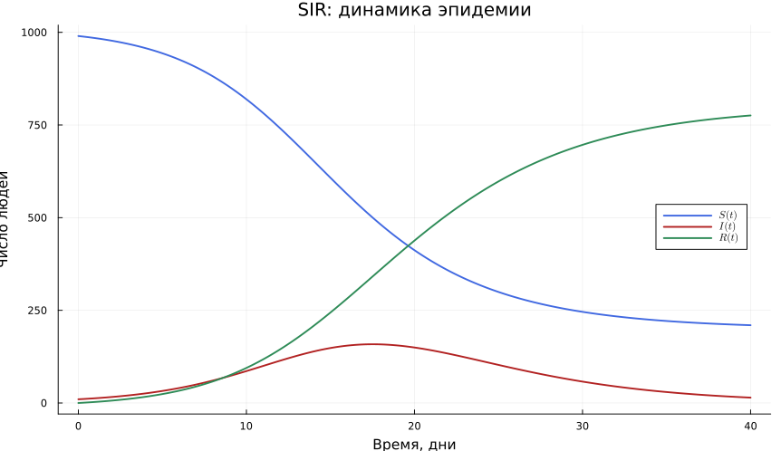

- $S$ уменьшается, $I$ проходит пик, $R$ возрастает
- численность $S+I+R$ сохраняется

## 4.4 Эффективное репродуктивное число

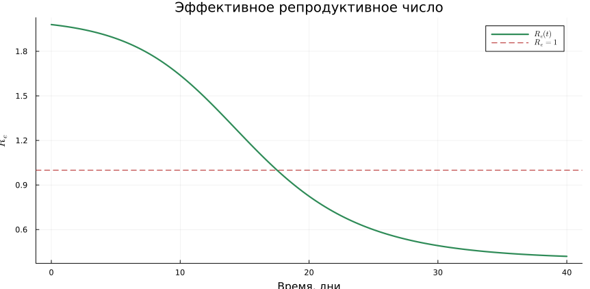

- начальное $R_0=2$
- после пересечения $R_e=1$ эпидемия затухает

## 4.5 Базовые результаты

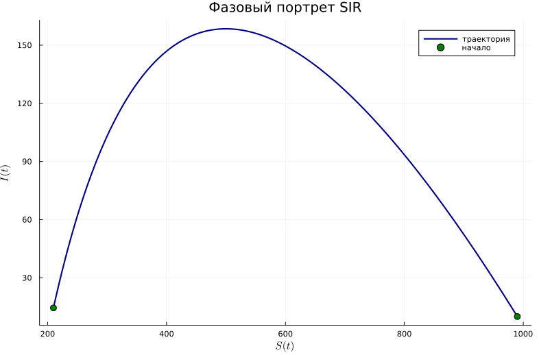

| Показатель | Значение |
| --- | --- |
| пик $I$ | 158,45 |
| время пика | 17,5 дня |
| $R(40)$ | 775,69 |
| ошибка баланса | $6{,}82\cdot10^{-13}$ |

## 4.6 Выполненный notebook SIR

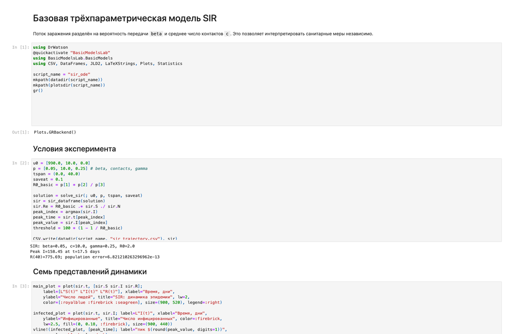

- сохранены вывод и сводная панель графиков
- ошибок выполнения нет

## 4.7 Результаты параметрической SIR

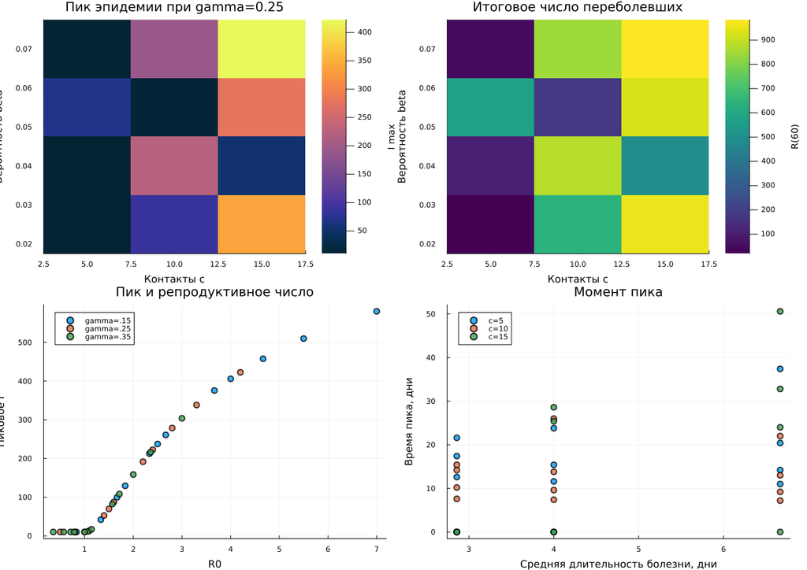

| Показатель | Минимум | Максимум |
| --- | --- | --- |
| $R_0$ | 0,357 | 7,000 |
| пик $I$ | 10,00 | 580,35 |
| $R(60)$ | 15,45 | 998,79 |

- сетка: 4 значения $\beta$, 3 значения $c$, 3 значения $\gamma$
- всего выполнено 36 сочетаний

## 4.8 Notebook параметрической SIR

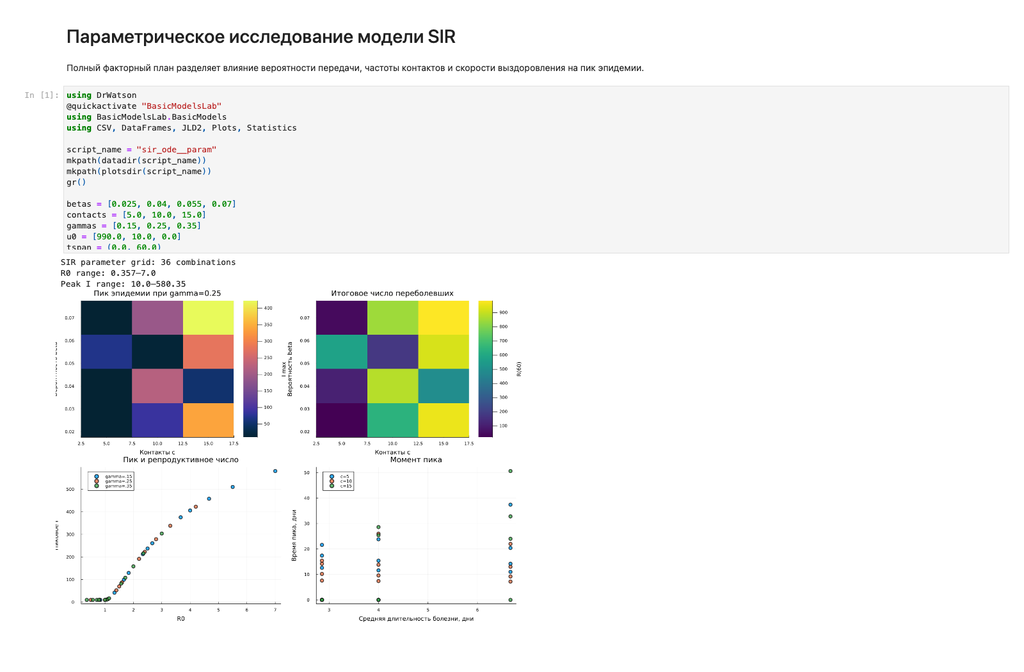

- выполнены все 36 сочетаний
- построены четыре сравнительные панели

# 5 Модель Лотки–Вольтерры

## 5.1 Уравнения, равновесие и интеграл

$$x'=\alpha x-\beta xy,\qquad y'=\delta xy-\gamma y.$$
$$(x^*,y^*)=(\gamma/\delta,\alpha/\beta),\qquad
V=\delta x-\gamma\ln x+\beta y-\alpha\ln y.$$

- $x$ — жертвы, $y$ — хищники
- равновесие является центром замкнутых орбит

## 5.2 Базовые параметры и динамика

| Параметр | Значение |
| --- | --- |
| $\alpha,\beta$ | 0,10; 0,02 |
| $\delta,\gamma$ | 0,01; 0,30 |
| $x_0,y_0$ | 40; 9 |
| равновесие | (30; 5) |

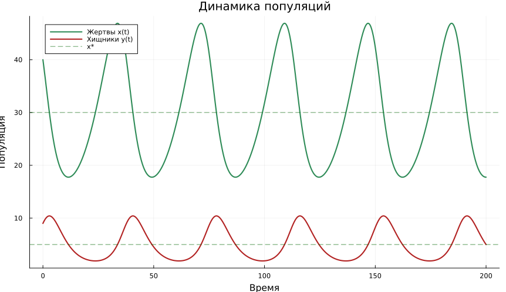

## 5.3 Фазовый портрет

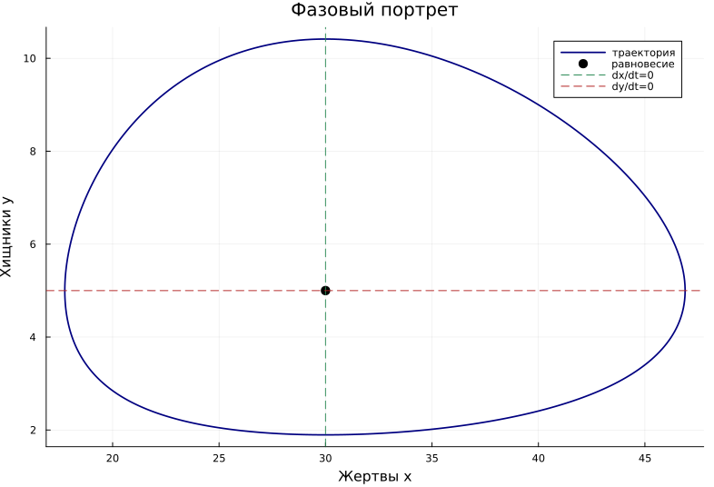

- орбита замкнута вокруг $(30;5)$
- пик хищников отстаёт от пика жертв на 6,9

## 5.4 Период и первый интеграл

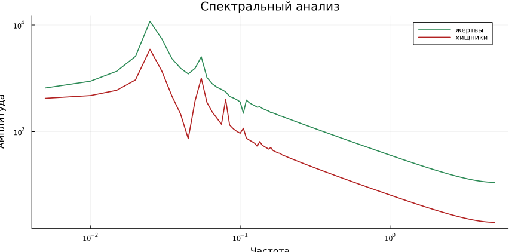

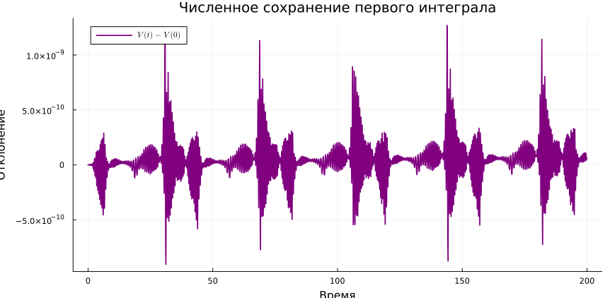

- период: 36,276 по линейной оценке и 40,020 по спектру
- максимальный дрейф $V$: $1{,}27\cdot10^{-9}$

## 5.5 Выполненный notebook модели

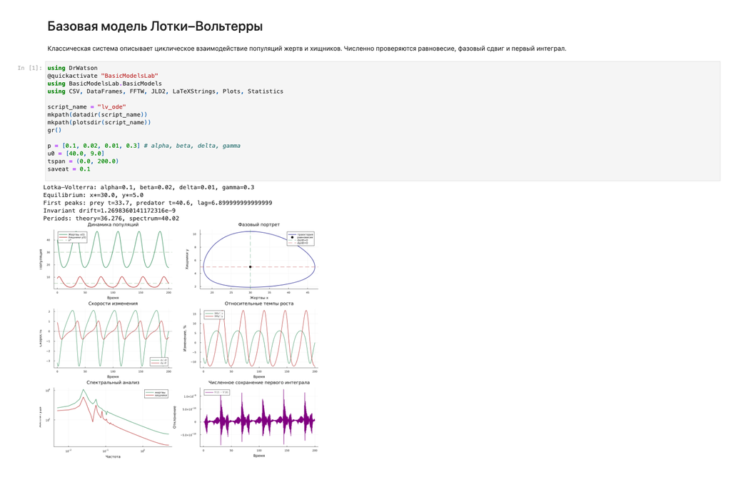

- показаны код, показатели и шесть графических панелей
- notebook выполнен без ошибок

# 6 Параметрическое исследование

## 6.1 План модели хищник–жертва

- $\alpha$: 0,05; 0,10; 0,20; 0,30
- $\gamma$: 0,10; 0,30; 0,50; 0,70
- $\beta=0{,}02$, $\delta=0{,}01$
- 16 сочетаний, горизонт 600
- периоды, амплитуды и дрейф $V$

[figure not shown]

## 6.2 Результаты серии Лотки–Вольтерры

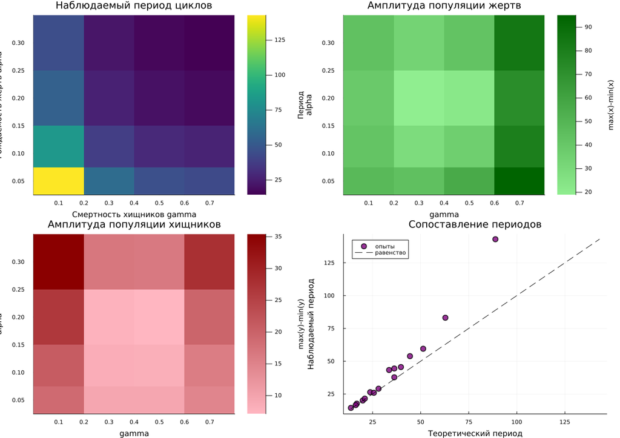

- период: 14,40–142,93
- максимум жертв: 40,14–128,03
- максимум хищников: 9,79–39,10

## 6.3 Выполненный параметрический notebook

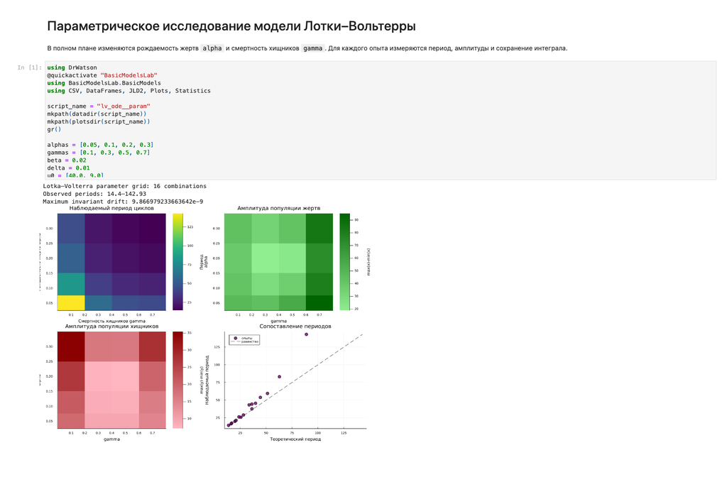

- выполнены все 16 сочетаний
- все периоды конечны
- дрейф интеграла меньше $10^{-8}$

# 7 Результаты

## 7.1 Проверка и производные форматы

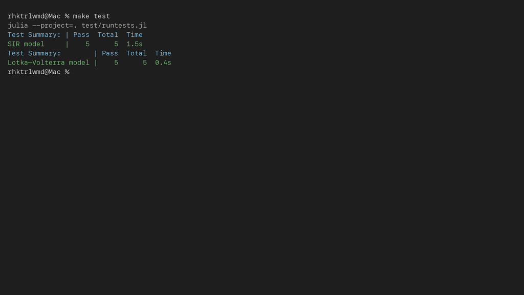

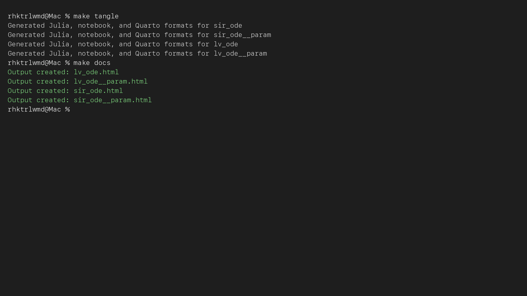

- 10 из 10 тестов пройдены
- получены 4 JL, 4 QMD, 4 HTML и 4 выполненных IPYNB

# 8 Выводы

## 8.1 Основные выводы

- Реализованы обе базовые модели главы 2
- Для SIR подтверждены баланс и порог $R_e=1$
- Для Лотки–Вольтерры подтверждены циклы и интеграл
- Выполнены 36 и 16 параметрических опытов
- Сохранены таблицы, графики и выполненные notebooks
- Все автоматические проверки завершены успешно